# Sahadeo_Lab 4

Rishi Sahadeo

2025-03-13

### Q0 - 0. How many duplicated records were removed from boxoffice data? What is your random seed number?

```r
set.seed(12345)

boxoffice <- read_csv("C:/Users/supaq/OneDrive/Desktop/Rutgers Courses/Statistical Inference for Data Science/Lab 4/movie_boxoffice-1.csv")
duplicates <- sum(duplicated(boxoffice))

boxoffice_cleaned <- distinct(boxoffice)

duplicates
```

```
## [1] 100
```

100 duplicates were removed from the data set.  
set.seed was set to 12345.

# Part 1: Sampling

### 1. Treat the box office data as your population. Have a histogram of the global box office earning. Describe the shape of the distribution

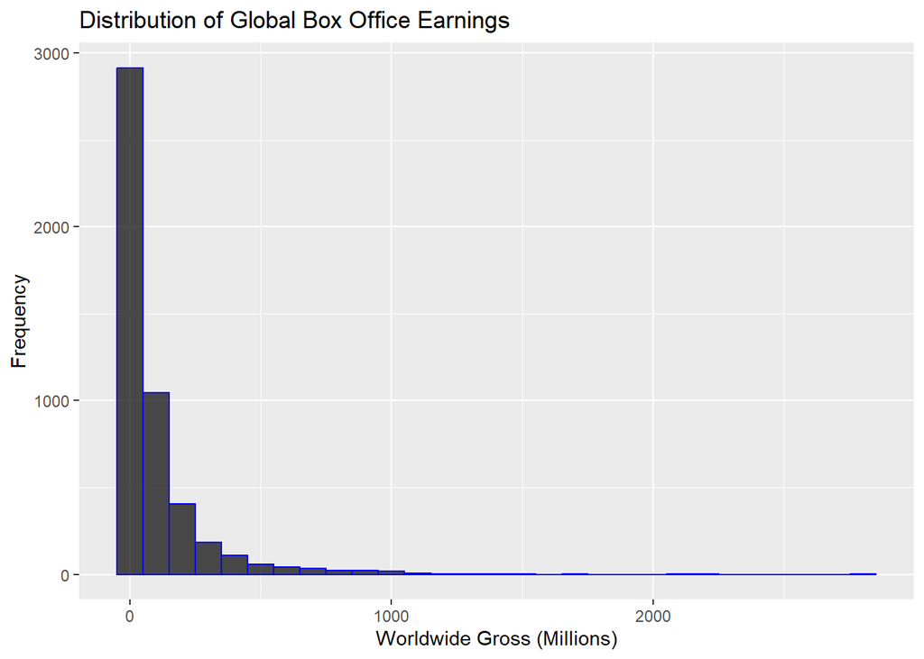

```r
ggplot(boxoffice_cleaned, aes(x = Worldwide_Gross)) +
  geom_histogram(binwidth = 100, fill = "black", color = "blue", alpha = 0.7) +
  labs(title = "Distribution of Global Box Office Earnings",
       x = "Worldwide Gross (Millions)",
       y = "Frequency")
```

The distribution of worldwide box office earnings is skewed to the right, suggesting most movies have low earnings. The highest bar shows that a large number of movies earned low amounts while some extreme outliers show movies earning over $1 billion. These extreme outliers stretch the tail to the right.

### 2. In the population, what is the average global box office earning? What is the standard deviation? What is the proportion of movies whose global box office earning exceeds budget?

```r
boxoffice_summary <- boxoffice_cleaned %>%
  summarize(global_mean = mean(Worldwide_Gross, na.rm = TRUE),
            global_sd = sd(Worldwide_Gross, na.rm = TRUE),
            exceeds_budget = mean(Worldwide_Gross > Budget, na.rm = TRUE))

boxoffice_summary
```

```
## # A tibble: 1 × 3
##   global_mean global_sd exceeds_budget
##         <dbl>     <dbl>          <dbl>
## 1      95.831    177.46        0.64613
```

The average global box office earning is $95.8 million.  
The standard deviation is $177 million.  
64.6% of global movies box office earnings, earned more than its budget.

### 3. Take a random sample of 200 movies from the population, get the histogram of global box office earning, and describe the shape of the distribution. You are going to use this sample in part II and future homework.

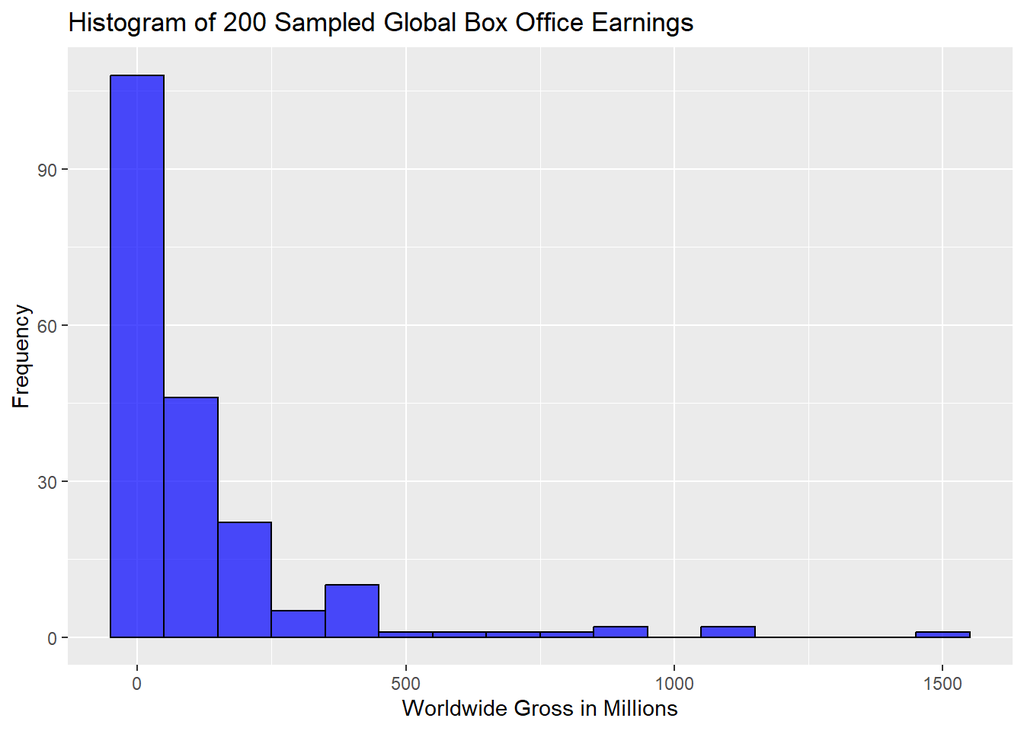

```r
sample_200 <- boxoffice_cleaned %>%
  sample_n(size = 200)

ggplot(sample_200, aes(x = Worldwide_Gross)) +
  geom_histogram(binwidth = 100, color = "black", fill = "blue", alpha = 0.7) +
  labs(title = "Histogram of 200 Sampled Global Box Office Earnings",
       x = "Worldwide Gross in Millions",
       y = "Frequency")
```

The distribution of the 200-sample global box office earnings is right-skewed, meaning most movies have low earnings, with a few outliers with higher earnings ~$500M - $1.5B. This sample’s distribution is similar to the full data set.

### 4. In your sample, what is the average global box office earning? What is the standard deviation? What is the proportion of movies whose global box office earning exceeds budget? Are these summary statistics from the sample close to those population parameters?

```r
sample_summary <- sample_200 %>%
  summarize(sample_mean = mean(Worldwide_Gross, na.rm = TRUE),
            sample_sd = sd(Worldwide_Gross, na.rm = TRUE),
            sample_prop_profit = mean(Worldwide_Gross > Budget, na.rm = TRUE))

sample_summary
```

```
## # A tibble: 1 × 3
##   sample_mean sample_sd sample_prop_profit
##         <dbl>     <dbl>              <dbl>
## 1      116.50    209.37               0.69
```

In my sample:

- The average global box office earning is $116.50 million.
- The standard deviation is $209.37 million.
- The proportion of movies whose global box office earning exceeds budget is 69%

Compared to the full population, these statistics are close, demonstrating that the sample provides a good estimate of the population parameters despite small variations.

### 5. Take a random sample of n movies from the population, calculate the average global box office earning, and the proportion of movies whose global box office earning exceeds budget. Repeat 500 times. (Do this step for n=20, 50, 100, 200 respectively)

n = 20

```r
sample_20 <- boxoffice_cleaned %>%
  rep_sample_n(size = 20, reps = 500) %>%
  group_by(replicate) %>%
  summarize(mean_20 = mean(Worldwide_Gross, na.rm = TRUE),
            sd_20 = sd(Worldwide_Gross, na.rm = TRUE),
            prop_profit_20 = mean(Worldwide_Gross > Budget, na.rm = TRUE))

summary_20 <- sample_20 %>%
  summarize(
  mean_of_means_20 = mean(mean_20),
  mean_of_sd_20 = mean(sd_20),
  mean_profitable_20 = mean(prop_profit_20)
)

sample_20
```

```
## # A tibble: 500 × 4
##    replicate mean_20   sd_20 prop_profit_20
##        <int>   <dbl>   <dbl>          <dbl>
##  1         1 113.26  170.65            0.7
##  2         2  73.478 139.58            0.55
##  3         3 119.83  235.64            0.6
##  4         4  70.967 100.60            0.6
##  5         5  64.860  93.185           0.7
##  6         6 111.37  232.94            0.75
##  7         7 108.18  168.49            0.7
##  8         8  76.447 104.73            0.6
##  9         9 169.40  241.32            0.7
## 10        10 145.96  210.98            0.5
## # ℹ 490 more rows
```

```r
summary_20
```

```
## # A tibble: 1 × 3
##   mean_of_means_20 mean_of_sd_20 mean_profitable_20
##              <dbl>         <dbl>              <dbl>
## 1           98.198        163.38             0.6418
```

The mean of means from the 500 samples of 20 movies is $98.198 million. The mean of the means of the standard deviation from the 500 samples of 20 movies is $163.38 million. The mean of the profitable movies from the 500 samples of 20 movies is 64.18%

n = 50

```r
sample_50 <- boxoffice_cleaned %>%
  rep_sample_n(size = 50, reps = 500) %>%
  group_by(replicate) %>%
  summarize(mean_50 = mean(Worldwide_Gross, na.rm = TRUE),
            sd_50 = sd(Worldwide_Gross, na.rm = TRUE),
            prop_profit_50 = mean(Worldwide_Gross > Budget, na.rm = TRUE))

summary_50 <- sample_50 %>%
  summarize(
    mean_of_means_50 = mean(mean_50),
    mean_of_sd_50 = mean(sd_50),
    mean_of_profitable_50 = mean(prop_profit_50)
  )

sample_50
```

```
## # A tibble: 500 × 4
##    replicate mean_50   sd_50 prop_profit_50
##        <int>   <dbl>   <dbl>          <dbl>
##  1         1 104.80  214.50            0.74
##  2         2  92.873 165.96            0.7
##  3         3 146.63  231.92            0.62
##  4         4  89.855 171.77            0.6
##  5         5 107.05  153.98            0.7
##  6         6 136.95  277.80            0.64
##  7         7  59.236  80.302           0.62
##  8         8  96.131 176.07            0.64
##  9         9 132.37  227.99            0.82
## 10        10  87.587 120.64            0.74
## # ℹ 490 more rows
```

```r
summary_50
```

```
## # A tibble: 1 × 3
##   mean_of_means_50 mean_of_sd_50 mean_of_profitable_50
##              <dbl>         <dbl>                 <dbl>
## 1           96.547        167.66               0.64736
```

The mean of means from the 500 samples of 50 movies is $96.547 million. The mean of the means of the standard deviation from the 500 samples is $167.66 million. The mean of the means of profitable movies from the 500 samples of 50 movies is 64.736%

n = 100

```r
sample_100 <- boxoffice_cleaned %>%
  rep_sample_n(size = 100, reps = 500) %>%
  group_by(replicate) %>%
  summarize(mean_100 = mean(Worldwide_Gross, na.rm = TRUE),
            sd_100 = sd(Worldwide_Gross, na.rm = TRUE),
            prop_profit_100 = mean(Worldwide_Gross > Budget, na.rm = TRUE))

summary_100 <- sample_100 %>%
  summarize(
    mean_of_means_100 = mean(mean_100),
    mean_of_sd_100 = mean(sd_100),
    mean_of_profitable_100 = mean(prop_profit_100)
  )

sample_100
```

```
## # A tibble: 500 × 4
##    replicate mean_100 sd_100 prop_profit_100
##        <int>    <dbl>  <dbl>           <dbl>
##  1         1  112.12  188.98            0.67
##  2         2   97.812 154.12            0.6
##  3         3   95.795 143.13            0.66
##  4         4  125.82  205.25            0.71
##  5         5  126.83  222.86            0.63
##  6         6   95.443 174.46            0.61
##  7         7  112.48  183.18            0.67
##  8         8  108.54  220.93            0.68
##  9         9   90.622 155.00            0.62
## 10        10   85.412 107.89            0.65
## # ℹ 490 more rows
```

```r
summary_100
```

```
## # A tibble: 1 × 3
##   mean_of_means_100 mean_of_sd_100 mean_of_profitable_100
##               <dbl>          <dbl>                  <dbl>
## 1            95.604         169.56                 0.6448
```

The mean of means from the 500 samples of 100 movies is $95.604 million. The mean of the means of the standard deviation from the 500 samples of 100 movies is $169.56 million. The mean of the mean of the profitable movies from the 500 samples of 100 movies is 64.48%

n = 200

```r
sample_200b <- boxoffice_cleaned %>%
  rep_sample_n(size = 200, reps = 500) %>%
  group_by(replicate) %>%
  summarize(mean_200b = mean(Worldwide_Gross, na.rm = TRUE),
            sd_200b = sd(Worldwide_Gross, na.rm = TRUE),
            prop_profit_200b = mean(Worldwide_Gross > Budget, na.rm = TRUE))

summary_200b <- sample_200b %>%
  summarize(
    mean_of_means_200 = mean(mean_200b),
    mean_of_sd_200 = mean(sd_200b),
    mean_of_profitable_200 = mean(prop_profit_200b)
  )

sample_200b
```

```
## # A tibble: 500 × 4
##    replicate mean_200b sd_200b prop_profit_200b
##        <int>     <dbl>   <dbl>            <dbl>
##  1         1    72.102  122.29            0.61
##  2         2   106.54   202.11            0.69
##  3         3    73.293  135.05            0.615
##  4         4    95.450  151.53            0.685
##  5         5    81.652  131.36            0.645
##  6         6    85.838  143.59            0.66
##  7         7   105.60   206.57            0.7
##  8         8    83.743  154.85            0.615
##  9         9   104.58   173.30            0.64
## 10        10   103.29   220.87            0.585
## # ℹ 490 more rows
```

```r
summary_200b
```

```
## # A tibble: 1 × 3
##   mean_of_means_200 mean_of_sd_200 mean_of_profitable_200
##               <dbl>          <dbl>                  <dbl>
## 1            94.678         171.88                0.64455
```

The mean of means of worldwide box office earnings from 500 samples of 200 movies is $94.678 million. The mean of the means for the standard deviation from the 500 samples of 200 movies is $171.88 million. The mean of the means of the proportion of profitable movies from the 500 samples of 200 movies is 64.45%

### 6. For each n=20, 50, 100 and 200, get the histogram of the average global box office earning. Have histograms using facet_wrap() so the four histograms are in the same picture for easy comparison. Also get the mean and standard error of the average global box office earning.

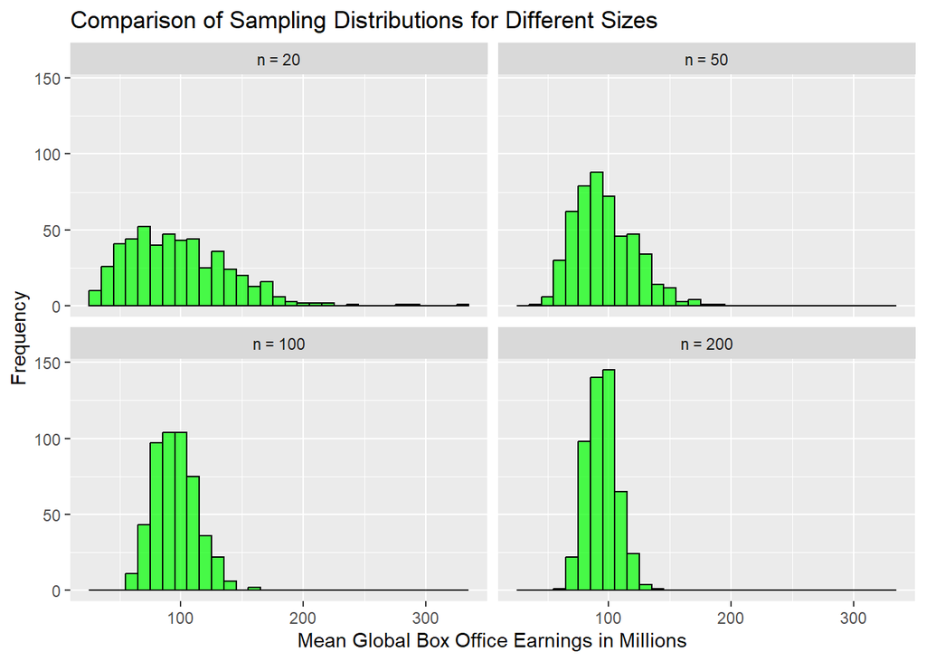

```r
combined_sample_means <- bind_rows(
  sample_20 %>% rename(mean_gross = mean_20) %>% mutate(n = "n = 20"),
  sample_50 %>% rename(mean_gross = mean_50) %>% mutate(n = "n = 50"),
  sample_100 %>% rename(mean_gross = mean_100) %>% mutate(n = "n = 100"),
  sample_200b %>% rename(mean_gross = mean_200b) %>% mutate(n = "n = 200")) %>%
  mutate(n = factor(n, levels = c("n = 20", "n = 50", "n = 100", "n = 200")))

ggplot(combined_sample_means, aes(x = mean_gross)) +
  geom_histogram(binwidth = 10, fill = "green", color = "black", alpha = 0.7) +
  facet_wrap(~n) +
  labs(title = "Comparison of Sampling Distributions for Different Sizes",
       x = "Mean Global Box Office Earnings in Millions",
       y = "Frequency")
```

Summary of samples

```r
combined_sample_summary <- combined_sample_means %>%
  group_by(n) %>%
  summarize(mean_of_means = mean(mean_gross),
            se_of_means = sd(mean_gross) / sqrt(n()))

combined_sample_summary
```

```
## # A tibble: 4 × 3
##   n       mean_of_means se_of_means
##   <fct>           <dbl>       <dbl>
## 1 n = 20         98.198     1.9166
## 2 n = 50         96.547     1.1050
## 3 n = 100        95.604     0.76916
## 4 n = 200        94.678     0.55263
```

### 7. Compare the distributions among different n values, and also compare them to the distribution from the population in Q1.

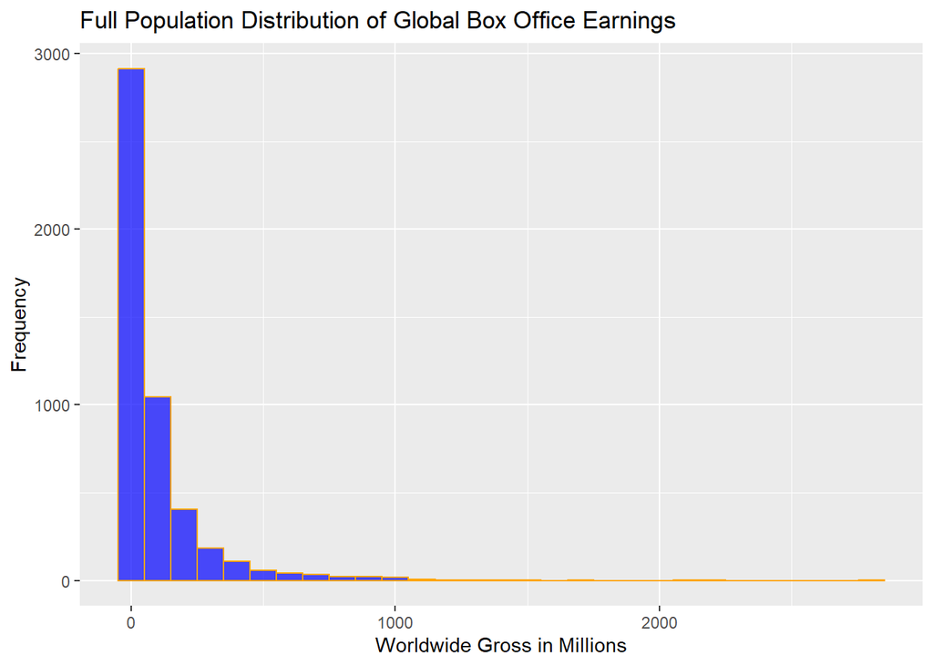

```r
ggplot(boxoffice_cleaned, aes(x = Worldwide_Gross)) +
  geom_histogram(binwidth = 100, color = "orange", fill = "blue", alpha = 0.7) +
  labs(title = "Full Population Distribution of Global Box Office Earnings",
       x = "Worldwide Gross in Millions",
       y = "Frequency")
```

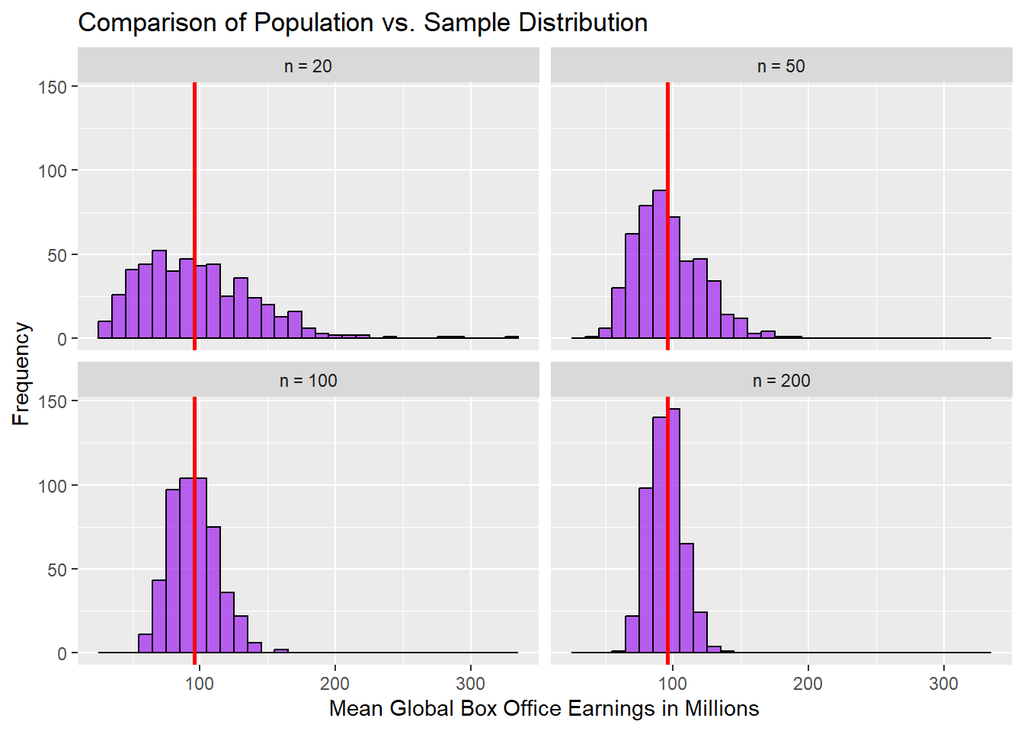

```r
ggplot(combined_sample_means, aes(x = mean_gross)) +
  geom_histogram(binwidth = 10, fill = "purple", color = "black", alpha = 0.7) +
  facet_wrap(~n) +
  geom_vline(aes(xintercept = mean(boxoffice_cleaned$Worldwide_Gross,
                                   na.rm = TRUE)), color = "red",
             linetype = "solid", linewidth = 1) +
  labs(title = "Comparison of Population vs. Sample Distribution",
       x = "Mean Global Box Office Earnings in Millions",
       y = "Frequency")
```

### 8. For each n=20, 50, 100 and 200, get the histogram of the proportion of movies whose global box office earning exceeds budget. Have histograms using facet_wrap() so the four histograms are in the same picture for easy comparison. Also get the mean and standard error of the proportion of movies whose global box office earnings exceed budget.

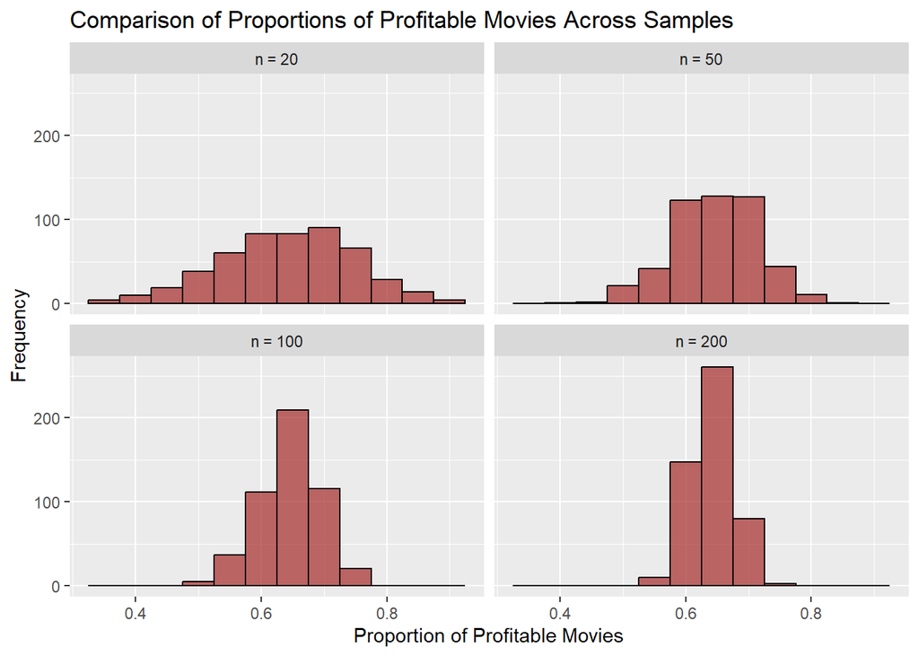

```r
combined_sampled_proportions <-bind_rows(
  sample_20 %>% rename(prop_profit = prop_profit_20) %>% mutate(n = "n = 20"),
  sample_50 %>% rename(prop_profit = prop_profit_50) %>% mutate(n = "n = 50"),
  sample_100 %>% rename(prop_profit = prop_profit_100) %>% mutate(n = "n = 100"),
  sample_200b %>% rename(prop_profit = prop_profit_200b) %>% mutate(n = "n = 200")
) %>%
  mutate(n = factor(n, levels = c("n = 20", "n = 50", "n = 100", "n = 200")))

ggplot(combined_sampled_proportions, aes(x = prop_profit)) +
  geom_histogram(binwidth = 0.05, fill = "brown", color = "black", alpha = 0.7) +
  facet_wrap(~n) +
  labs(title = "Comparison of Proportions of Profitable Movies Across Samples",
       x = "Proportion of Profitable Movies",
       y = "Frequency")
```

```r
sample_proportion_summary <- combined_sampled_proportions %>%
  group_by(n) %>%
  summarize(mean_of_props = mean(prop_profit),
            se_of_props = sd(prop_profit) / sqrt(n()))

sample_proportion_summary
```

```
## # A tibble: 4 × 3
##   n       mean_of_props se_of_props
##   <fct>           <dbl>       <dbl>
## 1 n = 20        0.6418    0.0047887
## 2 n = 50        0.64736   0.0030113
## 3 n = 100       0.6448    0.0021068
## 4 n = 200       0.64455   0.0014989
```

The histogram of smaller sample sizes where n = 20, 50 are slightly skewed, with more variability displayed with wider distributions. As n increases to 100 and 200, values cluster around the true proportion of 64.6%. Distributions become tighter and more normal, following the central limit theorem.

The mean proportions are very close to the population proportion. As n increases the standard error decreases allowing for more precise estimates.

### 9. Compare the distributions among different n values

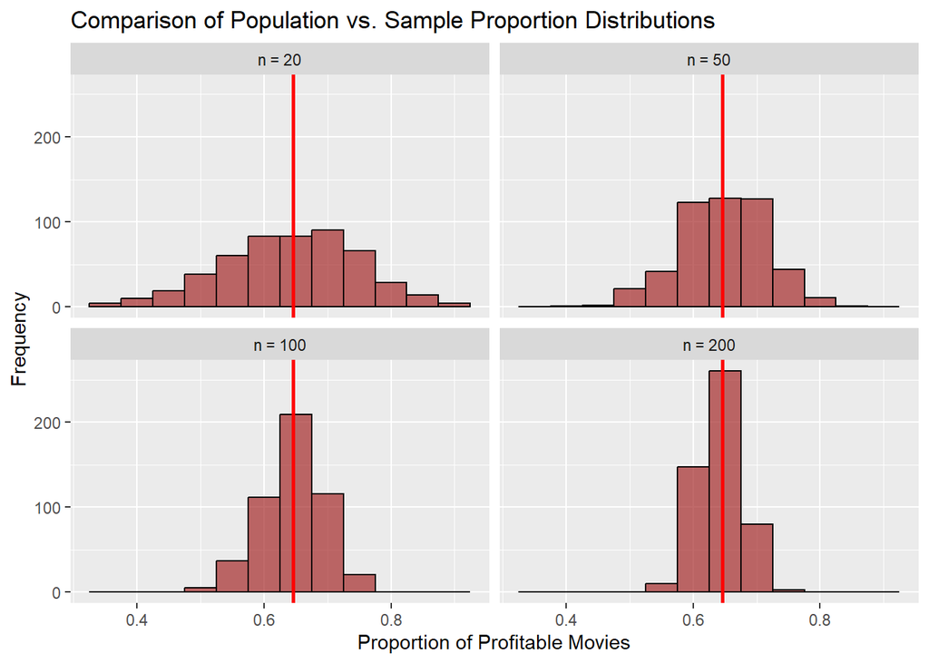

```r
ggplot(combined_sampled_proportions, aes(x = prop_profit)) +
  geom_histogram(binwidth = 0.05, fill = "brown", color = "black", alpha = 0.7) +
  facet_wrap(~n) +
  geom_vline(aes(xintercept = mean(boxoffice_cleaned$Worldwide_Gross >
                                     boxoffice_cleaned$Budget, na.rm = TRUE)),
             color = "red",
             linetype = "solid", linewidth = 1) +
  labs(title = "Comparison of Population vs. Sample Proportion Distributions",
       x = "Proportion of Profitable Movies",
       y = "Frequency")
```

# Part 2: Bootstrapping

### 10. Use data from Q3 as the initial sample, use bootstrapping method to resample once with 200 movies. Are there any duplicated movies in your bootstrap sample? Is this expected or something is wrong?

```r
bootstrap_sample <- sample_200 %>%
  rep_sample_n(size = 200, replace = TRUE)

duplicate_movies <- sum(duplicated(bootstrap_sample))

duplicate_movies
```

```
## [1] 77
```

Yes there are 77 duplicated movies in my bootstrap sample. This is expected since bootstrapping is used to approximate sampling variability. Each re sampled data set is drawn from the original sample with replacement, meaning some movies appear multiple times while others may not appear at all. If we didn’t sample with replacement we would just reshuffle the original sample.

### 11. Get the histogram of global box office earning in the bootstrap sample. Describe the shape of the distribution, and compare it to Q3

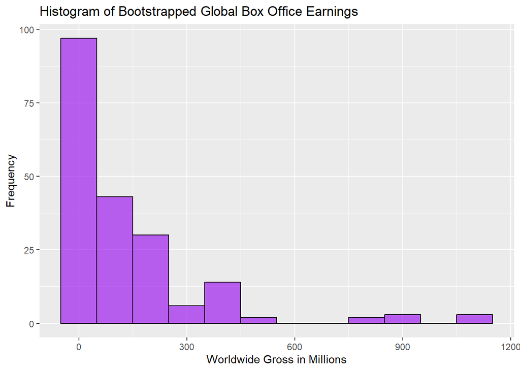

```r
ggplot(bootstrap_sample, aes(x = Worldwide_Gross)) +
  geom_histogram(binwidth = 100, color = "black", fill = "purple", alpha = 0.7) +
  labs(title = "Histogram of Bootstrapped Global Box Office Earnings",
       x = "Worldwide Gross in Millions",
       y = "Frequency")
```

The bootstrap distribution is right-skewed, similar to the distribution of the original 200 samples. The bootstrap sample preserves the shape of the original sample, even though variability if slightly lower, due to repeated selections. In both histograms most movies have low box office earnings, with a few extreme high-grossing movies creating a right tail. The range of earnings in the bootstrap sample closely resembles the structure of the original sample.

### 12. In the bootstrap sample in Q10, what is the average global box office earning? What is the standard deviation of it? What is the proportion of movies whose global box office earning exceeds budget? Are they close enough to those in the initial sample?

```r
bootstrap_summary <- bootstrap_sample %>%
  ungroup() %>%
  summarize(
    bootstrap_mean = mean(Worldwide_Gross, na.rm = TRUE),
    bootstrap_sd = sd(Worldwide_Gross, na.rm = TRUE),
    bootstrap_prop_profit = mean(Worldwide_Gross > Budget, na.rm = TRUE)
  )

bootstrap_summary
```

```
## # A tibble: 1 × 3
##   bootstrap_mean bootstrap_sd bootstrap_prop_profit
##            <dbl>        <dbl>                 <dbl>
## 1         135.31       205.32                  0.71
```

```r
sample_summary
```

```
## # A tibble: 1 × 3
##   sample_mean sample_sd sample_prop_profit
##         <dbl>     <dbl>              <dbl>
## 1      116.50    209.37               0.69
```

The average global box office earnings of the bootstrap sample is $135.31 million. The standard deviation of the bootstrap sample is $205.32 million. The proportion of movies whose global box office earnings exceeds budget is 71%

Compared to the initial sample, the bootstrap sample has a higher mean, the standard deviation is very close, only off by ~$4 million and the proportion of profitable movies is slightly higher by 2% in the bootstrap sample.

### 13. Get the bootstrapping distribution of the average global box office earning, and the proportion of movies whose global box office earning exceeds budget, by resampling 500 times with bootstrapping method. Get the mean and standard error of the average global box office earning. Get the mean and standard error of the proportion of movies whose global box office earning exceeds budget

```r
bootstrap_distribution <- sample_200 %>%
  rep_sample_n(size = 200, replace = TRUE, reps = 500) %>%
  group_by(replicate) %>%
  summarize(bootstrap_mean = mean(Worldwide_Gross, na.rm = TRUE),
            bootstrap_prop_profit = mean(Worldwide_Gross > Budget, na.rm = TRUE))

bootstrap_distribution
```

```
## # A tibble: 500 × 3
##    replicate bootstrap_mean bootstrap_prop_profit
##        <int>          <dbl>                 <dbl>
##  1         1        117.65                  0.7
##  2         2         88.786                 0.68
##  3         3        122.51                  0.72
##  4         4        121.99                  0.685
##  5         5        113.68                  0.7
##  6         6         88.448                 0.665
##  7         7        116.85                  0.69
##  8         8        103.39                  0.66
##  9         9        141.92                  0.68
## 10        10        113.49                  0.72
## # ℹ 490 more rows
```

```r
bootstrap_summary_dis <- bootstrap_distribution %>%
  summarize(
    mean_global_earnings = mean(bootstrap_mean),
    se_global_earnings = sd(bootstrap_mean),
    mean_prop_profits = mean(bootstrap_prop_profit),
    se_prop_profit = sd(bootstrap_prop_profit)
  )

bootstrap_summary_dis
```

```
## # A tibble: 1 × 4
##   mean_global_earnings se_global_earnings mean_prop_profits se_prop_profit
##                  <dbl>              <dbl>             <dbl>          <dbl>
## 1               116.84             15.376           0.69086       0.031489
```

The mean of the global earnings is $116.84 million and the mean of the proportion of profitable movies is 69.086%

### 14. Have the histogram of the sample mean and sample proportion from Q13. Have histogram using facet_wrap() to make comparison of the bootstrap distribution with those the in Q6 and Q8 when n=200. Describe the comparison.

First i will combine the sample distribution with the bootstrap distribution and display a histogram for the sample mean, using facet_wrap to compare the bootstrap sample to the samples from Q6 and Q8 specifically when n = 200. Then display a histogram for the sample proportion for profitable movies, using facet_wrap to compare the bootstrap sample to the samples from Q6 and Q8 specifically when n = 200.

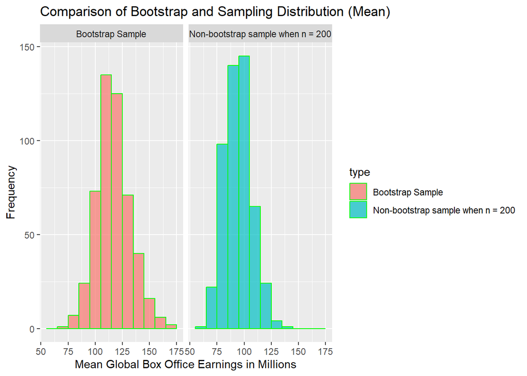

```r
combined_distributions <- bind_rows(
  bootstrap_distribution %>%
    rename(mean_gross = bootstrap_mean, prop_profit = bootstrap_prop_profit) %>%
    mutate(type = "Bootstrap Sample"),
  sample_200b %>%
    rename(mean_gross =  mean_200b, prop_profit = prop_profit_200b) %>%
    mutate(type = "Non-bootstrap sample when n = 200")
)

ggplot(combined_distributions, aes(x = mean_gross, fill = type)) +
  geom_histogram(binwidth = 10, color = "green", alpha = 0.7,
                 position = "dodge") +
  facet_wrap(~type) +
  labs(title = "Comparison of Bootstrap and Sampling Distribution (Mean)",
       x = "Mean Global Box Office Earnings in Millions",
       y = "Frequency")
```

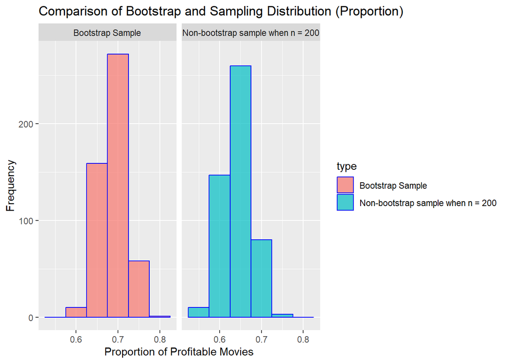

```r
ggplot(combined_distributions, aes(x = prop_profit, fill = type)) +
  geom_histogram(binwidth = 0.05, color = "blue", alpha = 0.7, position = "dodge") +
  facet_wrap(~type) +
  labs(title = "Comparison of Bootstrap and Sampling Distribution (Proportion)",
       x = "Proportion of Profitable Movies",
       y = "Frequency")
```

The bootstrap sample and proportion distributions are very similar, showing a bell shaped distribution centered around the means. The proportion of profitable movies has a slight right skew in both the bootstrap and sample distributions, but the spread is extremely close.